# Benchmarking SV callers from VCF Annot files

In this document, we will benchmark 5 SV callers (Delly, Manta, MELT, Wham, Svaba) generated from the workflow GATKsv and SvABA on the small NA12878 subset.

# 1. Read in the AnnotSV files and joining into a big master file

```r
NAsmall.delly <- read_tsv("AnnotSV_NAsmall_delly.tsv", show_col_types = FALSE)
NAsmall.manta <- read_tsv("AnnotSV_NAsmall_manta.tsv", show_col_types = FALSE)
NAsmall.melt <- read_tsv("AnnotSV_NAsmall_melt.tsv", show_col_types = FALSE)
NAsmall.wham <- read_tsv("AnnotSV_NAsmall_wham.tsv", show_col_types = FALSE)

NAsmall.svaba.indel <- read_tsv("AnnotSV_NAsmall_svaba_indel.tsv", show_col_types = FALSE)
NAsmall.svaba.sv <- read_tsv("AnnotSV_NAsmall_svaba_sv.tsv", show_col_types = FALSE)
```

First, we need to mark each entry with their respective callers:

```r
dim(NAsmall.delly)
```

```
[1] 36713   105
```

```r
dim(NAsmall.manta)
```

```
[1] 323 105
```

```r
dim(NAsmall.melt)
```

```
[1] 267 105
```

```r
dim(NAsmall.wham)
```

```
[1] 3182  105
```

```r
dim(NAsmall.svaba.indel)
```

```
[1] 136 105
```

```r
dim(NAsmall.svaba.sv)
```

```
[1] 377 105
```

Same variables (presumably with equal sizes), very different numbers of entries.

```r
# Do we need loops here?
NAsmall.delly$Caller <- "Delly"
NAsmall.manta$Caller <- "Manta"
NAsmall.melt$Caller <- "Melt"
NAsmall.wham$Caller <- "Wham"

NAsmall.svaba.indel$Caller <- "Svaba"
NAsmall.svaba.sv$Caller <- "Svaba"
```

```r
view(NAsmall.svaba.sv$Caller) # checks out
```

After creating the caller index for each dataset, we can now join these caller sets into a big, master file, called NAsmall.benchmark:

```r
# Merge() only takes two dfs (binary op). We need pipe:
join(NAsmall.delly, NAsmall.manta, type = "full") %>%
 join(NAsmall.melt, type = "full") %>%
  join(NAsmall.wham, type = "full") %>%
   join(NAsmall.svaba.indel, type = "full") %>%
    join(NAsmall.svaba.sv, type = "full") -> NAsmall.benchmark
```

Beware of the difference between plyr::join() and dplyr::merge…

```r
join(NAsmall.melt, NAsmall.manta, type = "full") -> NAsmall.mertest
dim(NAsmall.melt) + dim(NAsmall.manta) # checking dim sums
dim(NAsmall.mertest)
```

[output not shown]

```r
col.bench <- colnames(NAsmall.benchmark)
col.delly <- colnames(NAsmall.delly)
```

```r
is.na(col.bench) # the additional col 107 is problematic; missing value in col.others[107] == na
#is.na(col.delly)
```

```r
for (i in 1:107) {
    print(c(i, col.bench[i], col.delly[i]))[col.bench[i] != col.delly[i]]
}
```

```
[1] "1"          "AnnotSV_ID" "AnnotSV_ID"
[1] "2"        "SV_chrom" "SV_chrom"
[1] "3"        "SV_start" "SV_start"
[1] "4"      "SV_end" "SV_end"
[1] "5"         "SV_length" "SV_length"
[1] "6"       "SV_type" "SV_type"
[1] "7"          "Samples_ID" "Samples_ID"
[1] "8"  "ID" "ID"
[1] "9"   "REF" "REF"
[1] "10"  "ALT" "ALT"
[1] "11"   "QUAL" "QUAL"
[1] "12"     "FILTER" "FILTER"
[1] "13"   "INFO" "INFO"
[1] "14"     "FORMAT" "FORMAT"
[1] "15"            "NA12878_small" "NA12878_small"
```

[output cut: 95 more lines]

To address this:

```r
NAsmall.benchmark[107] <- NULL
dim(NAsmall.benchmark)
```

```
[1] 40998   106
```

We can now begin analysing our data.

# 2. Answering the Questions

## 2-1. Number and Types of variants detected by each method

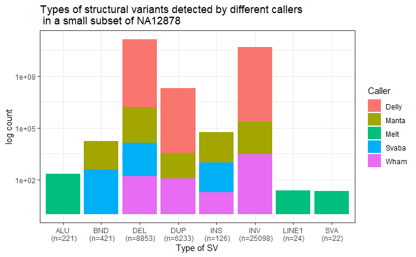

```r
#detach("package:plyr", unload = TRUE)

sample_size = NAsmall.benchmark %>% group_by(SV_type) %>% summarize(num=n())

NAsmall.benchmark %>%
  left_join(sample_size) %>%
  mutate(SV_Type = paste0(SV_type, "\n (n=", num, ")")) %>%

ggplot(aes(x = SV_Type, fill=Caller)) +
    geom_bar() + scale_y_log10() +
    theme_bw() +
    labs(x="Type of SV", y="log count") +
    ggtitle("Types of structural variants detected by different callers \n in a small subset of NA12878")
```

```r
#ggsave("SV_type_benchmark_NAsmall.png")
```

## 2-2. Number of variants detected by all methods

This one is trickier than it seems. It is actually asking:

> When intersecting all caller datasets, which SVs were detected by all methods?

In other words, we need to find the **SV locations** (or other universal feature) that were identically detected in every caller tested. Then, we need n(such SVs).

The idea is:

```
for(SV_start = SV_start && SV_end = SV_end)
      test_if (Caller1 != Caller2)
          if_so {
              keep testing until "Caller1 != any other callers" is TRUE;
          }
      else{
          next;
      }
```

…to search for every identical SVs detected by all callers.

Is there a more efficient & easier-to-program way?

```
"intersect"(NAsmall.caller1, NAsmall.caller2, by = "some_way_to_track_SV_ID") %>%
  intersect(., NAsmall.caller3) %>%
      ...

        intersect(, NAsmall.caller_n) -> variant.captured.by.all


dim(variant.captured.by.all)
```

In fact, using this method, we can do more with the resultant data frame (“variant.captured.by.all”)…

### 2-2-1. Using subset() to frame and filter the set “variant.captured.by.all”

Let’s subset(SV_start, SV_end, ID, Caller) from the master file:

```r
for.common.var <- subset(NAsmall.benchmark, select = c("SV_start", "SV_end", "SV_type", "ID", "Caller"))
# originally "ID" included
view(for.common.var)
```

Somehow, “ID” must be included for the Caller name to be displayed correctly.

> Must the ID be the same for those SVs who share the same location (i.e. same SV) and called by different callers? (i.e. Is ID based on caller, or location?)

NOPE. For example, both Manta and Svaba caught this variant:

| row | SV_start | SV_end | ID | Caller |
| --- | --- | --- | --- | --- |
| 36803 | 34889369 | 34889502 | MantaDEL:3561:0:0:0:0:0 | Manta |
| 40532 | 34889369 | 34889502 | 881414213 | Svaba |

```r
length(unique(NAsmall.benchmark$SV_start)) == nrow(NAsmall.benchmark)
```

…meaning there are (multiple, in fact) duplicates for the SV_start (and SV_end) columns…

> Note: What does the following dup-removal step do? Does it simply remove duplicates, or, that it removes different (massive subset!) variants called? (Primarily by Delly for some reason…)

```
You might want to skip the dup-cleaning step as it removes different variants (a lot of...) that were encompassed by the         large SV_start/end range (Hence not a good/unique marker).
```

```r
for.common.var.cleaned <- aggregate(for.common.var[5], for.common.var[-5], unique) # clean dup
```

```r
for.common.var.cleaned$ID <- NULL # remove the ID col
#common.variants2 <- aggregate(for.common.var.cleaned[4], for.common.var.cleaned[-4], unique) # callers unite; originally =3
```

```r
# preferred version
common.variants <- aggregate(for.common.var.cleaned[4], for.common.var.cleaned[-4],
                             FUN = function(X) paste(unique(X), collapse=", "))
```

Why is this not working after the update “ID” -> “SV_type”?

```r
str(common.variants$Caller)
```

```
 chr [1:1667] "Melt" "Melt" "Melt" "Melt" "Melt" "Melt" "Melt" "Melt" "Melt" "Melt" "Melt" "Melt" "Melt" "Melt" "Melt" ...
```

Now we just need to find those in Caller that have every caller present…

```r
# first we test
# grep(c("Svaba", "Manta"), common.variants$Caller) doesn't work because grep() doesn't take vectors with |v| > 1
grep("Svaba, Manta", common.variants$Caller)
```

```
 [1]  450  485  504  506  526  530  562  771  782  789  881  927  949  956  957  958  960 1376 1383 1400 1404 1417 1426 1434
```

Now we can proceed:

```r
grep("Svaba, Manta, Delly, Melt, Wham", common.variants$Caller)
```

```
integer(0)
```

To see first whether there is any entry at all that were captured by all callers, we use the old trick:

```r
table(as.factor(common.variants$Caller))
```

```
       Delly Delly, Manta        Manta         Melt        Svaba Svaba, Manta         Wham
         736            1          157          187          324           24          238
```

…and to summarise:

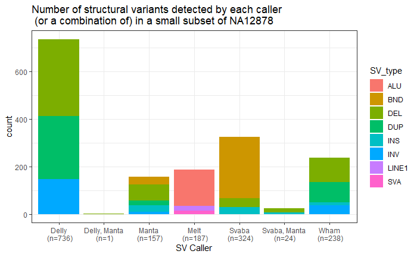

```r
sample_size = common.variants %>% group_by(Caller) %>% summarize(num=n())

common.variants %>%
  left_join(sample_size) %>%
  mutate(caller = paste0(Caller, "\n (n=", num, ")")) %>%

ggplot(aes(x = caller, fill=SV_type)) +
    geom_bar() +
    theme_bw() +
    labs(x="SV Caller", y="count") +
    ggtitle("Number of structural variants detected by each caller \n (or a combination of) in a small subset of NA12878")

ggsave("n_and_type_of_SV_by_caller_NAsmall.png")
```

## 2-3. Detected variants affecting coding regions (CDS) or ACMG class of variants

### 2-3-1. Data clean-up

```r
table(as.factor(NAsmall.benchmark$Location2))
```

```
      3'UTR       5'UTR 5'UTR-3'UTR   5'UTR-CDS         CDS   CDS-3'UTR         UTR
         15          88       27128          27         367          32       11642
```

```r
table(as.factor(Bench.profile$FILTER)) # QC to remove lowQUAL entries
```

```
                ac0                 hDP             LowQual            MaxDepth MaxDepth;MaxMQ0Frac   MaxDepth;SampleFT
                 39                  78               26749                  21                   2                   3
            MinQUAL    MinQUAL;SampleFT       NoPairSupport                PASS              Ploidy                 s25
                  9                  47                   1               13995                   2                   9
           SampleFT
                 43
```

We only want the PASS ones? So:

```r
Bench.cleaned <- filter(Bench.profile, FILTER == "PASS")
```

We can now focus on this dataset.

```r
table(as.factor(Bench.cleaned$ACMG_class))
```

```
      1       3       5  full=1  full=3  full=5 full=NA
    137     317       4      57     205    5083    7675
```

```r
table(as.factor(Bench.cleaned$SV_type))
```

```
  ALU   BND   DEL   DUP   INS   INV LINE1   SVA
  115   396  3020  2783   119  7536    13    13
```

```r
table(as.factor(Bench.cleaned$SV_chrom))
```

```
    1    10    11    12    13    14    15    16    17    18    19     2    20    21    22     3     4     5     6     7
11580     8    14     9    13     4    40    97     2     4     5    14  1477     4     2    32    60    14     7   588
    8     9     M     X
   12     2     4     3
```

```r
table(as.factor(Bench.cleaned$Caller))
```

```
Delly Manta  Melt Svaba  Wham
 9964   195   141   513  3182
```

### 2-3-2. Variants detected of ACMG class

Recall that ACMG classified variants into 5 major classes:

```
- Class 1. Benign

- Class 2. Likely benign

- Class 3. "VUS" == "Variants of Unknown Significance"

- Class 4. Likely pathogenic

- Class 5. Pathogenic
```

We will now analyse our filtered dataset to see how many of them belong to which ACMG class, and, where supplied, what the variant is known to relate to and what they have on their profile.

First, we noticed there are a lot of NA rows in the ACMG_class column. We need to remove them:

Also: full=1 vs 1?

Does it have to do with annotation mode? (Full=full SV classified => annotation_mode must be “split”?)

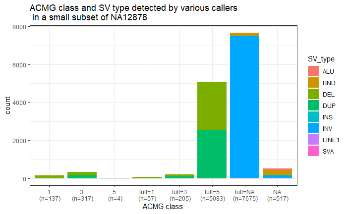

```r
sample_size = Bench.cleaned %>% group_by(ACMG_class) %>% summarize(num=n())

Bench.cleaned %>%
  left_join(sample_size) %>%
  mutate(ACMG.class = paste0(ACMG_class, "\n (n=", num, ")")) %>%

ggplot(aes(x = ACMG.class, fill=SV_type)) + # can try fill=Caller next
    geom_bar() +
    theme_bw() +
    labs(x="ACMG class", y="count") +
    ggtitle("ACMG class and SV type detected by various callers \n in a small subset of NA12878")
```

```r
#ggsave("n_and_type_of_SV_by_caller_NAsmall.png")
```

Interestingly:

```
- Most INV types have NA class;
- Of those non-NA class variants, full=5 are almost equally between DEL/DUP;
- Comparatively very few variants of class...wait. Let's remove the NA rows and log-y if necessary first...
```

```r
Bench.ACMG <- filter(Bench.cleaned, ACMG_class != c("full=NA", "NA"))
```

```
longer object length is not a multiple of shorter object length
```

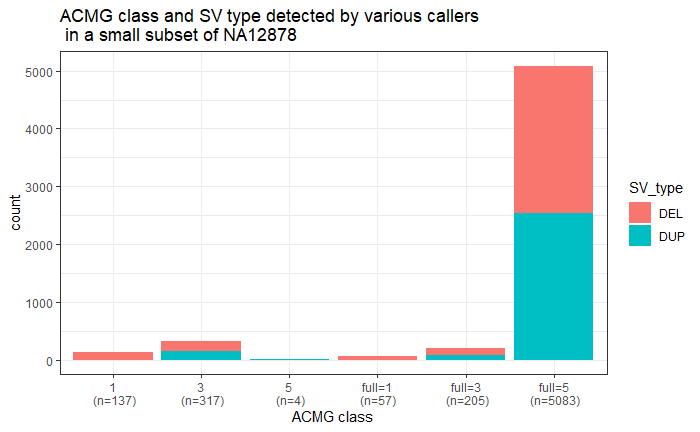

```r
sample_size = Bench.ACMG %>% group_by(ACMG_class) %>% summarize(num=n())

Bench.ACMG %>%
  left_join(sample_size) %>%
  mutate(ACMG.class = paste0(ACMG_class, "\n (n=", num, ")")) %>%

ggplot(aes(x = ACMG.class, fill=SV_type)) + # can try fill=Caller next
    geom_bar() +
    theme_bw() +
    labs(x="ACMG class", y="count") +
    ggtitle("ACMG class and SV type detected by various callers \n in a small subset of NA12878")
```

Remarkably — it’s just DEL/DUP now!

I want to know that of those displaying full=x, are they due to annotation_mode and is somewhat unnecessary to set apart them from normal “1,3,5”’s.

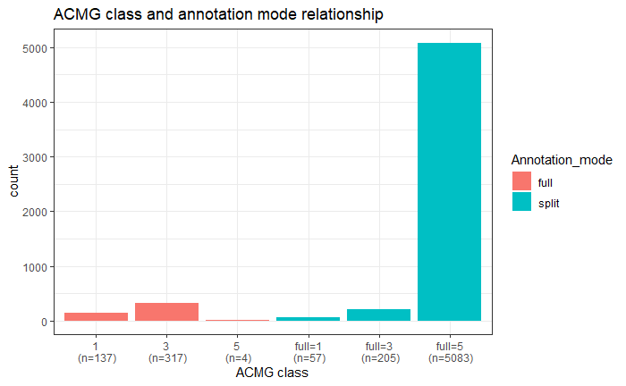

```r
sample_size = Bench.ACMG %>% group_by(ACMG_class) %>% summarize(num=n())

Bench.ACMG %>%
  left_join(sample_size) %>%
  mutate(ACMG.class = paste0(ACMG_class, "\n (n=", num, ")")) %>%

ggplot(aes(x = ACMG.class, fill=Annotation_mode)) + # can try fill=Caller next
    geom_bar() +
    theme_bw() +
    labs(x="ACMG class", y="count") +
    ggtitle("ACMG class and annotation mode relationship")
```

Indeed (!) — the “full” was only to signify that the entire SV (which was “split” into genes during annotation) were considered of ACMG class {1,3,5}. This means that if we were only concerned with the severity of the SV, we do not necessarily need to know whether they are “full” or not (It doesn’t give more info as no “mixed state” SVs are present at all in this dataset).

We proceed to combine the two classes.

```r
Bench.ACMG[Bench.ACMG == "full=1"] <- "1"
Bench.ACMG[Bench.ACMG == "full=3"] <- "3"
Bench.ACMG[Bench.ACMG == "full=5"] <- "5"
```

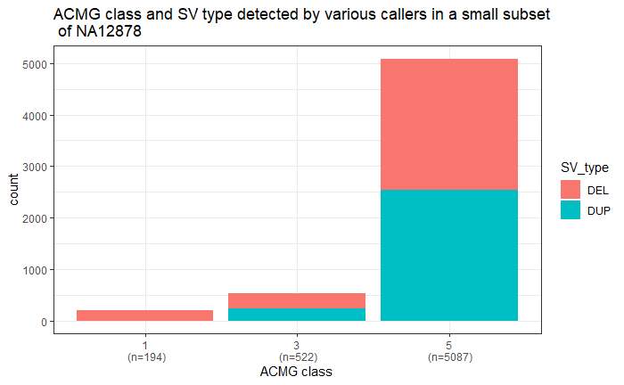

```r
sample_size = Bench.ACMG %>% group_by(ACMG_class) %>% summarize(num=n())

Bench.ACMG %>%
  left_join(sample_size) %>%
  mutate(ACMG.class = paste0(ACMG_class, "\n (n=", num, ")")) %>%

ggplot(aes(x = ACMG.class, fill=SV_type)) + # can try fill=Caller next
    geom_bar() +
    theme_bw() +
    labs(x="ACMG class", y="count") +
    ggtitle("ACMG class and SV type detected by various callers in a small subset \n of NA12878")

ggsave("ACMG_class_SV_type_benchmark_NAsmall.png")
```

### 2-3-3. Variants affecting CDS

```r
table(as.factor(NAsmall.benchmark$Location2))
```

```
      3'UTR       5'UTR 5'UTR-3'UTR   5'UTR-CDS         CDS   CDS-3'UTR         UTR
         15          88       27128          27         367          32       11642
```

> Does 5’UTR-3’UTR mean the SV spans from upstream-CDS, across the CDS, and encompasses the 3’UTR?

If so, then the “variants affecting CDS” include:

```
- Those that have Location2 == "CDS";
- Those that have Location2 == c("5'UTR-CDS", "CDS-3'UTR");
- Those that have Location2 == "5'UTR-3'UTR"

[******|------5'UTR------|---------------CDS--------------|-----3'UTR-----|*****]
```

We noticed that we didn’t import the “Location2” (Gene topology) column into the Bench.profile data frame. Let’s do that:

```r
Bench.profile$Gene_topology <- NAsmall.benchmark$Location2 # import the raw Location2 col into raw subset profile
Bench.cleaned <- filter(Bench.profile, FILTER == "PASS") # filter PASS
```

Let’s see:

```r
table(as.factor(Bench.cleaned$Gene_topology))
```

```
      3'UTR       5'UTR 5'UTR-3'UTR   5'UTR-CDS         CDS   CDS-3'UTR         UTR
          9          66        8973          11         261          17        3683
```

```r
table(as.factor(Bench.cleaned$FILTER)) ## double checking
```

```
 PASS
13995
```

Now, we filter all those variants that affect CDS and store them in a new df:

```r
Bench.CDS <- subset(Bench.cleaned, Gene_topology == c("CDS", "5'UTR-CDS", "CDS-3'UTR", "5'UTR-3'UTR"))
```

There are several things interesting about this data set that we want to know, since it affects the CDS region.

First:

```r
table(as.factor(Bench.CDS$Gene_topology))
```

[output not shown]

We notice the data frame was truncated. This is due to a mis-use of the “==” operator. See https://stackoverflow.com/questions/25647470/filter-multiple-values-on-a-string-column-in-dplyr.

In short, what we need was

```r
Bench.CDS <- filter(Bench.cleaned, Gene_topology %in% c("CDS", "5'UTR-CDS", "CDS-3'UTR", "5'UTR-3'UTR"))
```

```r
table(as.factor(Bench.CDS$Gene_topology))
```

```
5'UTR-3'UTR   5'UTR-CDS         CDS   CDS-3'UTR
       8973          11         261          17
```

Let’s get cracking.

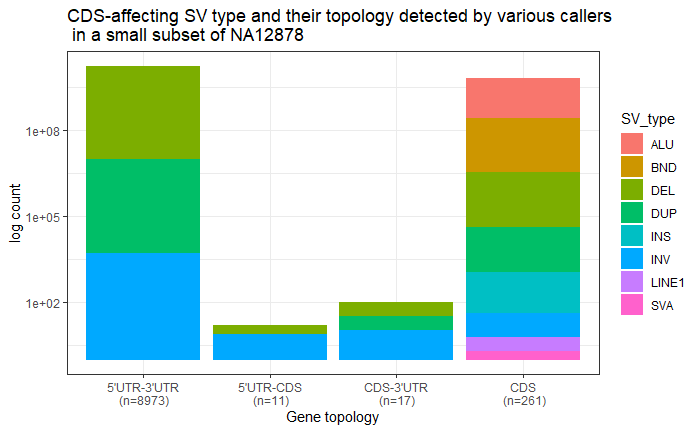

```r
sample_size = Bench.CDS %>% group_by(Gene_topology) %>% summarize(num=n())

Bench.CDS %>%
  left_join(sample_size) %>%
  mutate(Topos = paste0(Gene_topology, "\n (n=", num, ")")) %>%

ggplot(aes(x = Topos, fill=SV_type)) + # can try fill=Caller, Gene_name, GenCC... next
    geom_bar() + scale_y_log10() +
    theme_bw() +
    labs(x="Gene topology", y="log count") +
    ggtitle("CDS-affecting SV type and their topology detected by various callers \n in a small subset of NA12878")

ggsave("CDS_SV_type_benchmark_NAsmall.png")
```

From here on, I want to create a profile for those SVs detected that specifically affect CDS (including 5’UTR-3’UTR).

```r
subset(Bench.CDS, select = c("SV_chrom", "CytoBand", "Gene_name", "ACMG_class", "GenCC_disease", "GenCC_moi", "GenCC_classification", "Caller", "Gene_topology")) %>%
  filter(., Gene_topology %in% c("CDS", "5'UTR-3'UTR")) -> Bench.CDS.profile
```

I am interested in the following:

```
- 1. I want to know if the majority, if not all, of those SVs classified as "5'UTR-3'UTR" were detected by Delly?

- 2. I want to see of those SVs detected that has documentation on GenCC AND has non-trivial classification, what the genes affected are, their MOI, and the classification details.

- 3. (Continued from 2) I also want to know who called those SVs as an overview.
```

### 2-3-4. Answering more questions from our CDS-SV profile

#### 2-3-4-1. The first Q

… can be answered with a bar plot:

```r
table(as.factor(Bench.CDS.profile$Caller))
```

```
Delly Manta  Melt Svaba  Wham
 6962    35    29   113  2095
```

```r
table(as.factor(Bench.CDS.profile$Gene_topology))
```

```
5'UTR-3'UTR         CDS
       8973         261
```

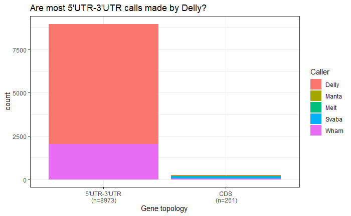

```r
sample_size = Bench.CDS.profile %>% group_by(Gene_topology) %>% summarize(num=n())

Bench.CDS.profile %>%
  left_join(sample_size) %>%
  mutate(Topos = paste0(Gene_topology, "\n (n=", num, ")")) %>%

ggplot(aes(x = Topos, fill=Caller)) +
    geom_bar() + #scale_y_log10() +
    theme_bw() +
    labs(x="Gene topology", y="count") +
    ggtitle("Are most 5'UTR-3'UTR calls made by Delly?")
```

#### 2-3-4-2. The second Q

> Of those SVs detected that has documentation on GenCC AND has non-trivial classification,

```
- What are the affected genes?
- What are their MOI?
- What are their classification details?
```

```r
filter(Bench.CDS.profile, !is.na(GenCC_classification) == TRUE) %>%
  filter(., GenCC_classification != "Limited") -> Bench.CDS.elite
```

The genes, MOI, and classification details, are all in the resultant data frame.

```r
write_csv(Bench.CDS.elite, "CDS_SV_elite_set.csv")
```

#### 2-3-4-3. The third Q

```r
table(as.factor(Bench.CDS.elite$Caller))
```

```
Delly Manta  Melt Svaba  Wham
 1096     5     9    16   324
```

```r
table(as.factor(Bench.cleaned$Caller)) # as a basis comparison
```

```
Delly Manta  Melt Svaba  Wham
 9964   195   141   513  3182
```

Potentially, we could do a crude rate analysis answering:

> “What is the approximate rate of this caller calling a significant SV?”

and by “significant”, we mean that the caller must pass the filter tests and belong to the elite set.

The tests were:

```
- (1) FILTER == "PASS";
- (2) Affect CDS (via Location2 or equivalently, Gene_topology)
- (3) Has significant entry in GenCC;
- (4) (Omittible) Affect either only CDS or the entirety of 5'UTR-3'UTR.
```

# 3. Questions we can’t (?) answer yet using just the AnnotSV files

There are two remaining questions that seem a bit more complicated:

```
Q5. What is the number of detected variants with XX number of "supporting reads"?
Q6. What is the (a) Precision, (b) Recall, and (c) F Score of ..., using the "consensus list" of NA12878?
```

To answer these questions we need to do a bit of read & search, and of course, I think, to start in a new notebook (as we might require vcfR and GenomicRanges…).